# Reproducible Research: Peer Assessment 1

## Loading and preprocessing the data

```r
#kill scientific notation
options(scipen=999)

if (!file.exists('activity.csv')) {
        unzip('activity.zip', exdir='../')
}

df <- read.csv('activity.csv')

#convert the intervals into date-time strings
#this adds today's date to every time, which is incorrect, but will be ignored
#converting into full date-time objects removes jumps on the x-axis e.g. 855 to 900
df$interval <- as.POSIXct(strptime(sprintf('%04d', df$interval), '%H%M'))

#lubridate for date-time evaluation
#loading packages near first call for to explain use
library(lubridate)
df$date <- ymd(df$date)
```

## What is mean total number of steps taken per day?

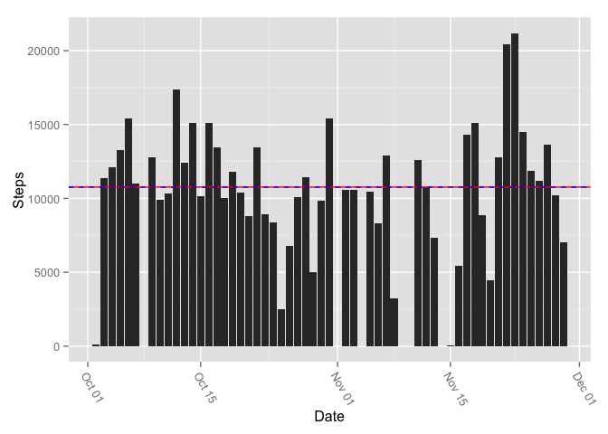

```r
#chain operations with dplyr
library(dplyr)
df.daily <- df %>%
        group_by(date) %>%
        summarize(steps.total = sum(steps))

steps.mean <- mean(df.daily$steps.total, na.rm = T)
steps.median <- median(df.daily$steps.total, na.rm = T)

library(ggplot2)

g.daily <- ggplot(df.daily, aes(date, steps.total)) +
        geom_histogram(stat = 'identity') +
        xlab('Date') + ylab('Steps') +
        theme(axis.text.x = element_text(angle = 300, hjust = 0)) +
        #because the mean and median are so close, overlap dashed blue on top of solid red to see both
        geom_hline(yintercept = steps.mean, linetype = 'solid', color = 'red') +
        geom_hline(yintercept = steps.median, linetype = 'dashed', color = 'blue')

g.daily
```

Most devices registered between 0 and 22,000 steps per day. The mean total of steps taken per day is 10766.1886792 (red line) and the median total is 10765 (blue line).

## What is the average daily activity pattern?

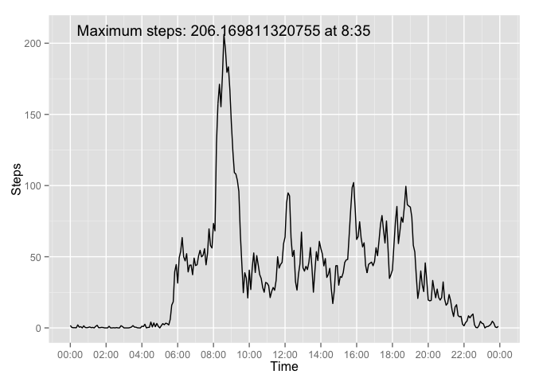

```r
df.intvl <- df %>%
        group_by(interval) %>%
        summarize(steps.mean = mean(steps, na.rm = T))

interval.max <- df.intvl[which.max(df.intvl$steps.mean),]

#Question asked for a plot, the code below works, but I like using ggplot so that is what I present.
#plot(df.intvl, type = 'l')

#scales package for better control of the x-axis labels
library(scales)

g.intvl <- ggplot(df.intvl, aes(interval, steps.mean)) +
        geom_line() +
        scale_x_datetime(breaks = date_breaks("2 hours"),
                         labels=date_format("%H:%M")) +
        xlab('Time') + ylab('Steps') +
        annotate('text', x = interval.max[[1]], y = interval.max[[2]] + 3,
                 label = paste('Maximum steps:', interval.max[[2]],'at 8:35'))
g.intvl
```

The interval with the maximum number of steps is 8:35 (going to work). There are also local maxima at 12:05 (lunch), 3:55 (leaving work?), and 6:50 (going out for the evening?)

## Imputing missing values

```r
df.nas <- sum(is.na(df))
```

There are 2304 intervals with missing values in the dataset.

```r
#create new data frame with a NA's replaced by interval averages
df.replace <- df %>%
        group_by(interval) %>%
        mutate(steps = ifelse(is.na(steps),
                              #i've seen as.integer recommended here, but I think fractional steps are acceptable.
                              mean(steps, na.rm=TRUE),
                              steps))
```

If we set every missing value equal to the mean of its interval, it changes our previous average daily activity patterns.

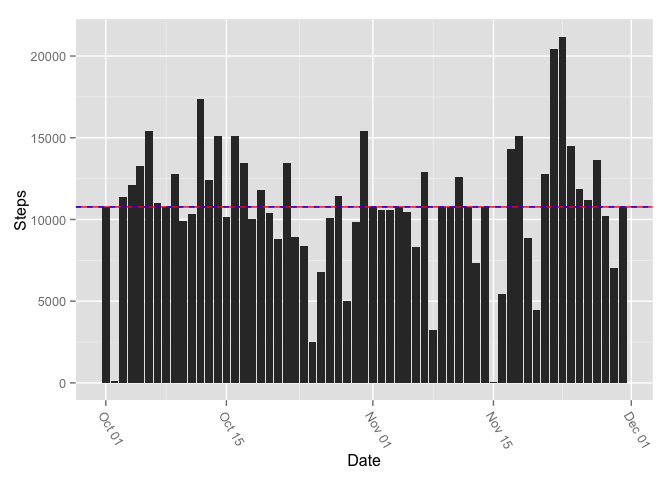

```r
#same code from above with new data frame
df.replace.daily <- df.replace %>%
        group_by(date) %>%
        summarize(steps.total = sum(steps))

steps.replace.mean <- mean(df.daily$steps.total, na.rm = T)
steps.replace.median <- median(df.daily$steps.total, na.rm = T)

g.replace.daily <- ggplot(df.replace.daily, aes(date, steps.total)) +
        geom_histogram(stat = 'identity') +
        xlab('Date') + ylab('Steps') +
        theme(axis.text.x = element_text(angle = 300, hjust = 0)) +
        geom_hline(yintercept = steps.replace.mean, linetype = 'solid', color = 'red') +
        geom_hline(yintercept = steps.replace.median, linetype = 'dashed', color = 'blue')

g.replace.daily
```

## Are there differences in activity patterns between weekdays and weekends?

To find out, first we assign whether a datapoint happened on a weekday or weekend, and then we aggregrate the means according to both interval and whether it’s a weekday or weekend.

```r
df.replace$date <- as.POSIXct(df.replace$date)
df.replace$Day <- as.factor(wday(df.replace$date, label = T))
levels(df.replace$Day) <- list('Weekend' = c('Sat', 'Sun'),
                               'Weekday' = c('Mon', 'Tues', 'Wed', 'Thurs', 'Fri'))

df.replace.intvl <- df.replace %>%
        group_by(Day, interval) %>%
        summarize(steps = mean(steps))
head(df.replace.intvl)
```

```
## Source: local data frame [6 x 3]
## Groups: Day
##
##       Day            interval       steps
## 1 Weekend 2015-02-12 00:00:00 0.214622642
## 2 Weekend 2015-02-12 00:05:00 0.042452830
## 3 Weekend 2015-02-12 00:10:00 0.016509434
## 4 Weekend 2015-02-12 00:15:00 0.018867925
## 5 Weekend 2015-02-12 00:20:00 0.009433962
## 6 Weekend 2015-02-12 00:25:00 3.511792453
```

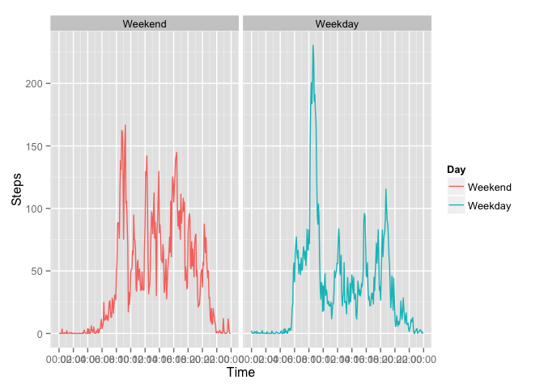

```r
#Instructions ask for lattice plot, but I find the side by sides hard to read. Code below does work though.
#library(lattice)
#xyplot(steps ~ interval | Day, df.replace.intvl, type = 'l')
g.replace.intvl <- ggplot(df.replace.intvl, aes(x = interval, y = steps, col = Day)) +
        geom_line() +
        scale_x_datetime(breaks = date_breaks("2 hours"),
                         labels=date_format("%H:%M")) +
        xlab('Time') + ylab('Steps') +
        #I think this makes it harder to read, but the question really wants it.
        facet_grid(. ~ Day)
g.replace.intvl
```

In some respects, weekend activity mirrors weekday activity. Local maxima are found around 8:30, 12:00, and 4:00. On the other hand, weekday activity skews strongly towards the morning spike, while weekend activity is distributed more evenly throughout the day.